# CENG 4515 Data Science and Analytics | Final

Beyza Kurt - 160709017

1/17/2021

# 1. Introduction

```r
# Load the caret package
library(caret)
library(skimr)
library(rlang)
library(RANN)
library(randomForest)
library(fastAdaboost)
library(gbm)
library(xgboost)
library(caretEnsemble)
library(C50)
library(earth)
library(e1071)
library(naivebayes)
library(mda)
library(zeallot)
```

In order to make the project comprehensive, I wanted to write a script in communication with the user rather than proceeding with default values. Accordingly, the users have to enter:

- - Dataset’s csv file’s full path on their computer or
  - Dataset’s csv file’s name if it is in the same location as script or
  - Dataset’s csv file’s link if it’s a file on the internet
- The number of the column to be used as the final grade label
- The name of the preprocessing method (the list is given)
- The name of the transformation method (the list is given)
- The name of the training method (the list is given)

In addition, in order to keep the events in the script under the user’s control, users will need to answer the following questions:

- After preprocessing is applied to the training data

  “*Do you want to see feature plots (y/n):*”
- Before creating training models with different methods

  “*Would you like to see the Model Accuracies and Variable Importance plots of the training models? one-by-one (1) or in direct comparison (2)?*”
- After creating at least 3 training models

  “*Do you want to continue for more models (y/n):*”

Apart from these, the program uses this function and waits for the user to press enter after each output that the user may want to examine.

```r
wait_user <- function() {
  readline(prompt = "\n(Press enter to skip)\n")
}
```

# 2. Script

- There is a function for each section.
- There is a main function as the wrapper function that runs all functions.

First of all, I will examine each section with short explanations without outputs. Later, I will show how all the code works with the Online Shoppers Intertion data set by running it in a section. However, since the system cannot take inputs from user while creating the html file, I will modify the code in this way and use it.

> Commands that affect the visual of the program and interaction with the user, such as writeLines ("") or wait_user(), will not be included in the code sections written to examine the functions.

## Variables

First of all, since I will explain the functions first, I would like to explain the variables that are in the parameters of the functions but are calculated or found in the main function, that is, the function we will see last.

| Variable Name | Variable Value |
| --- | --- |
| n_col | the number of columns of the original dataset |
| y_column_no | the number of the column to be used as the final grade label |
| columns | list, contains all columns’ names according to the location of the original dataset |
| answer | response from the user represents decisions made |
| all_models | list, contains all training models |
| all_models_names | character group, contains all traning methods’ names |

### 2.1.1. Import Dataset

```r
import_df <- function() {
  ds_path = readline(prompt = "Enter the dataset's path for 'read.csv()' command:
                               (full path, name or link) ");
  df <- read.csv(ds_path)
  return(df)
}
```

This function imports the dataset by using the string taken from user.

### 2.1.2. Data Exploration

```r
exploration <- function(df, n_col) {
  # The internal structure of dataset
  print(str(df))

  writeLines("First 4 columns and their first 6 rows:\n")
  print(head(df[, 1:4]))

  n_col_3 <- n_col - 3

  writeLines("\nLast 4 columns and their first 6 rows:\n")
  print(head(df[, n_col_3 : n_col]))
}
```

This function presents the internal structure of the dataset that is taken as a parameter, and its the first and last 4 columns with their first 6 rows in order to explore the data.

### 2.1.3. Data Preparation

```r
preparation <- function(df, y_column_no) {
  set.seed(100)

  # Step 1: Get row numbers for the train data
  trainRowNumbers <- createDataPartition(df[,y_column_no], p=0.8, list=FALSE)

  # Step 2: Create the training  dataset
  trainData <- df[trainRowNumbers,]

  # Step 3: Create the test dataset
  testData <- df[-trainRowNumbers,]

  # Store Y for later use
  y = as.factor(trainData[,y_column_no])

  skimmed <- skim(trainData)
  writeLines("\nFor The Training Data:")
  print(skimmed)

  return(list(trainData, testData, x, y))
}
```

This selects 80 percent of the dataset whick is taken as parameter, to use for training. It stores the remaining 20 percent to be used for testing, and the final grade label as “y” for later use. Finally, it presents a broad overview of the dataset.

### 2.1.4. Data Preprocessing

```r
preprocessing <- function(trainData, y, columns, y_column_no) {

  # Missing Data Imputation

  methods <- '  "BoxCox", "YeoJohnson", "expoTrans", "center", "scale", "range",
  "knnImpute", "bagImpute", "medianImpute", "pca", "ica",
  "spatialSign", "corr", "zv", "nzv", "conditionalX"'
  writeLines(methods)
  preprocess_method = readline(prompt = "Enter the preprocessing method from above list: ");

  # With the selected method, a preprocessing model is created to find missing data
  preProcess_missingdata_model <- preProcess(trainData, method=paste(preprocess_method))

  writeLines("About Preproccessing Model")
  print(preProcess_missingdata_model)

  # Model is applied to our training dataset
  trainData <- predict(preProcess_missingdata_model, newdata = trainData)

  writeLines("After using this model to predict the missing values in trainData,")
  writeLines(paste("Is there any missing data?", anyNA(trainData)))


  # Converting Categorical Variables

  # Dummy variables are converting a categorical variable to
  # as many binary variables as here are categories
  dummies_model <- dummyVars(as.formula( paste(columns[y_column_no], " ~ .") ), data = trainData)
  writeLines("Dummy variables that is converting a categorical variable to as many binary variables as\nhere are categories, are created.\n")

  # Model is applied to our training dataset
  trainData_mat <- predict(dummies_model, newdata = trainData)
  trainData <- data.frame(trainData_mat)

  # The internal structure of the train data
  print(str(trainData))


  # Transform The Data

  methods <- '  1. range: Normalize values so it ranges between 0 and 1
  2. center: Subtract Mean
  3. scale: Divide by standard deviation
  4. BoxCox: Remove skewness leading to normality. Values must be > 0
  5. YeoJohnson: Like BoxCox, but works for negative values.
  6. expoTrans: Exponential transformation, works for negative values.
  7. pca: Replace with principal components'
  writeLines(methods)

  transform_method = readline(prompt = "Enter the name of the transformation method from above list: ");

  # With the selected method, a preprocessing model is created to transform the data
  preProcess_transformation_model <- preProcess(trainData, method=paste(transform_method))

  # Model is applied to our training dataset
  trainData <- predict(preProcess_transformation_model, newdata = trainData)

  # The final grade label is added to training dataset
  trainData[[ columns[y_column_no] ]] <- y

  # The internal structure of the train data
  print(str(trainData))

  return(list(trainData, preProcess_missingdata_model, dummies_model, preProcess_transformation_model))
}
```

This function does 3 basic things:

- Missing data imputation

  It creates a preprocessing model by taking the name of the method from user, to find missing data, shares it with users and applies this to the train data. After applying, it checks is there any missing data in train data.
- Converting categorical variables

  It creates dummy variables that are converting a categorical variable to as many binary variables as here are categories, and applies this to the train data. After applying, it presents the internal structure of the train dataset.

  > But there is a problem here: Some of the categorical columns are not perceived as categorical due to their form. Therefore, they are treated like a continuous column, without being categorized. The solution to this problem, on the other hand, does not always give correct results if the programs do it themselves. Solutions involving the user can be produced, but I could not deal with this issue as I was not able to run my time.
- Transform the data

  It creates a transformation model by taking the name of the method from user, to transform the form of the data, and applies this to the train data. After applying, it adds “y” variable as the final grade label column to the train data. Then, it presents the internal structure of the train dataset.

### 2.1.5. Feature Plots

```r
show_feature_plots <- function(trainData, columns, y_column_no) {
  # plot except the final grade label
  n_col_train <- ncol(trainData)
  n_col_train_1 <- n_col_train - 1

  writeLines("\nBox plot is loading...")
  show(featurePlot(x = trainData[, 1:n_col_train_1],
              y = trainData[[ columns[y_column_no] ]],
              plot = "box",
              strip=strip.custom(par.strip.text=list(cex=.7)),
              scales = list(x = list(relation="free"),
                            y = list(relation="free"))))

  writeLines("Density plot is loading...")
  show(featurePlot(x = trainData[, 1:n_col_train_1],
              y = trainData[[ columns[y_column_no] ]],
              plot = "density",
              strip=strip.custom(par.strip.text=list(cex=.7)),
              scales = list(x = list(relation="free"),
                            y = list(relation="free"))))
}
```

Its aim is very simple: to plot box and density plots of the train data.

### 2.1.6. Training

```r
training <- function(trainData, answer, all_models_names, columns, y_column_no) {
  set.seed(100)

  methods <- '  "knn", "naive_bayes", "lda", "rpart", "adaboost",
  "bagFDAGCV", "parRF", "rf", "rfRules", "RRF", "gbm",
  "xgbDART", "xgbLinear", "xgbTree", "bag", "C5.0"
  "C5.0Cost", "C5.0Rules", "C5.0Tree", "fda", "bagEarth",
  "bagEarthGCV", "earth", "gcvEarth", "bagFDA", "ranger",
  "svmLinear2", "svmLinearWeights", "ordinalRF", "treebag"'
  writeLines(methods)

  training_method = readline(prompt = "  Enter the training method from above list:
  (There are more than these but this script's libraries contains them)");

  writeLines("\nThe model is being trained...")
  training_model = train(as.formula( paste(columns[y_column_no], " ~ .") ), data=trainData, method=paste(training_method))

  # For being able to name the models in the list that contains all models
  all_models_names <- c(all_models_names, paste(training_method))

  if (answer == 1){
    writeLines("\nModel Accuracies plot loading...")
    try(show(plot(training_model, main="Model Accuracies")))

    writeLines("Variable Importance plot loading...")
    varimp <- varImp(training_model)
    show(plot(varimp, main="Variable Importance"))
  }

  return(list(training_model, all_models_names))
}
```

It creates a training model by taking the method’s name from the user. Also, it adds method’s name to the all_models_names list to use later.

If the user answered “yes” to the question “Would you like to see the Model Accuracies and Variable Importance plots of the training models”, it prints the Model Accuracies and Variable Importance plots.

### 2.1.7. Prediction

```r
prediction <- function(testData, preProcess_missingdata_model, dummies_model, preProcess_transformation_model, answer) {
  # Step 1: Impute missing values
  testData2 <- predict(preProcess_missingdata_model, testData)

  # Step 2: Create one-hot encodings (dummy variables)
  testData2 <- predict(dummies_model, testData2)

  # Step 3: Transform the features with selected method
  testData2 <- predict(preProcess_transformation_model, testData2)

  # The internal structure of the test data
  writeLines("Test data after preprocessing models are applied:")
  print(str(data.frame(testData2)))

  return(testData2)
}
```

It applies the models we created in the “Preprocessing” step to the test data set and presents the internal structure of it.

### 2.1.8. Performance Evaluation

```r
performance_evaluation <- function(testData, testData2, training_model, columns, y_column_no) {
  # Test data is predicted by using training model
  fitted <- predict(training_model, testData2)

  # Calculates a cross-tabulation of observed and predicted classes with associated statistics
  show(caret::confusionMatrix(reference = as.factor(testData[[ columns[y_column_no] ]]), data = fitted, mode='everything'))
}
```

It makes predictions on test data using the training model which is taken as a parameter. Then, it calculates a cross-tabulation of observed and predicted classes with associated statistics.

### 2.1.9. Comparison

```r
comparison <- function(all_models) {
  # Model performances are compared
  models_compare <- resamples(all_models)

  # Summary of the models performances
  summary(models_compare)

  # Box plots to compare models
  scales <- list(x=list(relation="free"), y=list(relation="free"))
  writeLines("\nModel Compare plot is loading...")
  show(bwplot(models_compare, scales=scales))
}
```

It compares the performances of all training models created, presents the summary of the comparison and visualizes it with the box plot.

## 2.2. Main

```r
main <- function() {
  # Import the Dataset
  df <- import_df()

  n_col <- ncol(df) # to be used in many functions
  exploration(df, n_col)   # Data Exploration

  y_column_no = readline(prompt = "  Enter the number of the column to be used as the final grade label:
  For example 18 for 'online_shoppers_intention.csv'");
  y_column_no = as.integer(y_column_no);

  # Data Preparation
  c(trainData, testData, y) %<-% preparation(df, y_column_no)

  # all names according to the location of the original data set
  # This is used when specific column names are required
  columns <- names(df)

  # Data Preprocessing
  c(trainData, preProcess_missingdata_model, dummies_model, preProcess_transformation_model) %<-% preprocessing(trainData, y, columns, y_column_no)

  answer = readline(prompt = "Do you want to see feature plots (y/n):")
  answer <- "no"
  if (toupper(answer) == "Y" || toupper(answer) == "YES") {
    show_feature_plots(trainData, columns, y_column_no)
  }

  answer = readline("  Would you like to see the Model Accuracies and Variable Importance plots
  of the training models? one-by-one (1) or in direct comparison (2)? ")
  answer <- as.integer(answer)

  all_models <- list()      # to keep all training models
  all_models_names <- c()   # to keep all training models names

  cont <- "yes"
  # To create the desired number of training models
  while (toupper(cont) == "Y" || toupper(cont) == "YES") {
    # Training
    c(training_model, all_models_names) %<-% training(trainData, answer, all_models_names, columns, y_column_no)

    # add new training model to list
    all_models <- c(all_models, list(training_model))

    # Comparison can be made after at least 3 models
    if (length(all_models) > 2) {
      cont = readline(prompt = "Do you want to continue for more models (y/n):")
    }

  }

  # Names in the list are replaced with the names of models
  names(all_models) <- all_models_names

  # Comparison of Models
  comparison(all_models)

  # Application of preprocessing steps to the test data
  testData2 <- prediction(testData, preProcess_missingdata_model, dummies_model, preProcess_transformation_model)

  # Predictions
  writeLines(toupper("Predicting Test Data with All Models"))
  for (i in 1:length(all_models)) {
    writeLines(paste(i, ". For", toupper(all_models_names[[i]]), "model:"))
    performance_evaluation(testData, testData2, all_models[[i]], columns, y_column_no)
  }
}
```

Our main function that we will call “wrapper function”.

1. Imports the dataset with import_df()
2. Creates “n_col” variable
3. Explores the dataset with exploration()
4. Takes “y_column_no” variable from the user
5. Do preparations with preparation()
6. Creates “columns” variable
7. Make preprocessing with preprocessing()
8. Takes “answer” variable from the user
9. Depend on the “answer” variable, shows plots with show_feature_plots()
10. Takes a new “answer” variable from the user
11. Creates an empty list named “all_models”
12. Creates an empty characther group named “all_models_names”
13. Creates “cont” variable with “yes” value
14. Depend on the “cont” variable;
- Creates a training model
- Adds model to the “all_models” list
- Asks the user if they want to change the value of the “cont” variable
15. Changes “all_models” names with “all_models_names”
16. Compares all models with comparison()
17. Applies all preproccessing models to the test data with prediction()
18. Predictes the test data with all training models with performance_evaluation()

# 3. Demostrate

I rearranged the code so that it does not require input from the user. Accordingly;

- Uses the file “online_shoppers_intention.csv”, which is supposed to be in the same location as the script, as the data set.
- Uses “knnImpute” method for missing values and “range” method for transformation in preprocessing step.
- Uses the value “18” for the variable “y_column_no” and ’c (" knn “,” naive_bayes “,” lda “,” earth “,” fda “)’ for”all_models_names"
- Creates training models with “all_models_names” values as methods
- Prints “Model Accuracies” and “Variable Importance” plots for each model, and feature plots for the training set.

*I am not including the code part so that the report is not filled with the same codes over and over. But I will send this code too.*

```
## IMPORT DATASET
##
## Enter the dataset's path for 'read.csv()' command: online_shoppers_intention.csv
## (full path, name or link)
##
##
## DATA EXPLORATION
##
## 'data.frame':    12330 obs. of  18 variables:
##  $ Administrative         : int  0 0 0 0 0 0 0 1 0 0 ...
##  $ Administrative_Duration: num  0 0 0 0 0 0 0 0 0 0 ...
##  $ Informational          : int  0 0 0 0 0 0 0 0 0 0 ...
##  $ Informational_Duration : num  0 0 0 0 0 0 0 0 0 0 ...
##  $ ProductRelated         : int  1 2 1 2 10 19 1 0 2 3 ...
##  $ ProductRelated_Duration: num  0 64 0 2.67 627.5 ...
##  $ BounceRates            : num  0.2 0 0.2 0.05 0.02 ...
##  $ ExitRates              : num  0.2 0.1 0.2 0.14 0.05 ...
##  $ PageValues             : num  0 0 0 0 0 0 0 0 0 0 ...
##  $ SpecialDay             : num  0 0 0 0 0 0 0.4 0 0.8 0.4 ...
##  $ Month                  : Factor w/ 10 levels "Aug","Dec","Feb",..: 3 3 3 3 3 3 3 3 3 3 ...
##  $ OperatingSystems       : int  1 2 4 3 3 2 2 1 2 2 ...
##  $ Browser                : int  1 2 1 2 3 2 4 2 2 4 ...
##  $ Region                 : int  1 1 9 2 1 1 3 1 2 1 ...
##  $ TrafficType            : int  1 2 3 4 4 3 3 5 3 2 ...
##  $ VisitorType            : Factor w/ 3 levels "New_Visitor",..: 3 3 3 3 3 3 3 3 3 3 ...
##  $ Weekend                : logi  FALSE FALSE FALSE FALSE TRUE FALSE ...
##  $ Revenue                : logi  FALSE FALSE FALSE FALSE FALSE FALSE ...
## NULL
##
## First 4 columns and their first 6 rows:
##
##   Administrative Administrative_Duration Informational Informational_Duration
## 1              0                       0             0                      0
## 2              0                       0             0                      0
## 3              0                       0             0                      0
## 4              0                       0             0                      0
## 5              0                       0             0                      0
## 6              0                       0             0                      0
##
## Last 4 columns and their first 6 rows:
```

[output cut: 169 more lines]

```
##  $ OperatingSystems             : num  0 0.143 0.286 0.286 0.143 ...
##  $ Browser                      : num  0 0.0833 0.0833 0.1667 0.0833 ...
##  $ Region                       : num  0 0 0.125 0 0 0.25 0 0.125 0 0.375 ...
##  $ TrafficType                  : num  0 0.0526 0.1579 0.1579 0.1053 ...
##  $ VisitorType.New_Visitor      : num  0 0 0 0 0 0 0 0 0 0 ...
##  $ VisitorType.Other            : num  0 0 0 0 0 0 0 0 0 0 ...
##  $ VisitorType.Returning_Visitor: num  1 1 1 1 1 1 1 1 1 1 ...
##  $ WeekendFALSE                 : num  1 1 1 0 1 1 0 1 1 1 ...
##  $ WeekendTRUE                  : num  0 0 0 1 0 0 1 0 0 0 ...
##  $ Revenue                      : Factor w/ 2 levels "FALSE","TRUE": 1 1 1 1 1 1 1 1 1 1 ...
## NULL
##
## Do you want to see feature plots (y/n): y
##
## Box plot of The Train Data is loading...
```

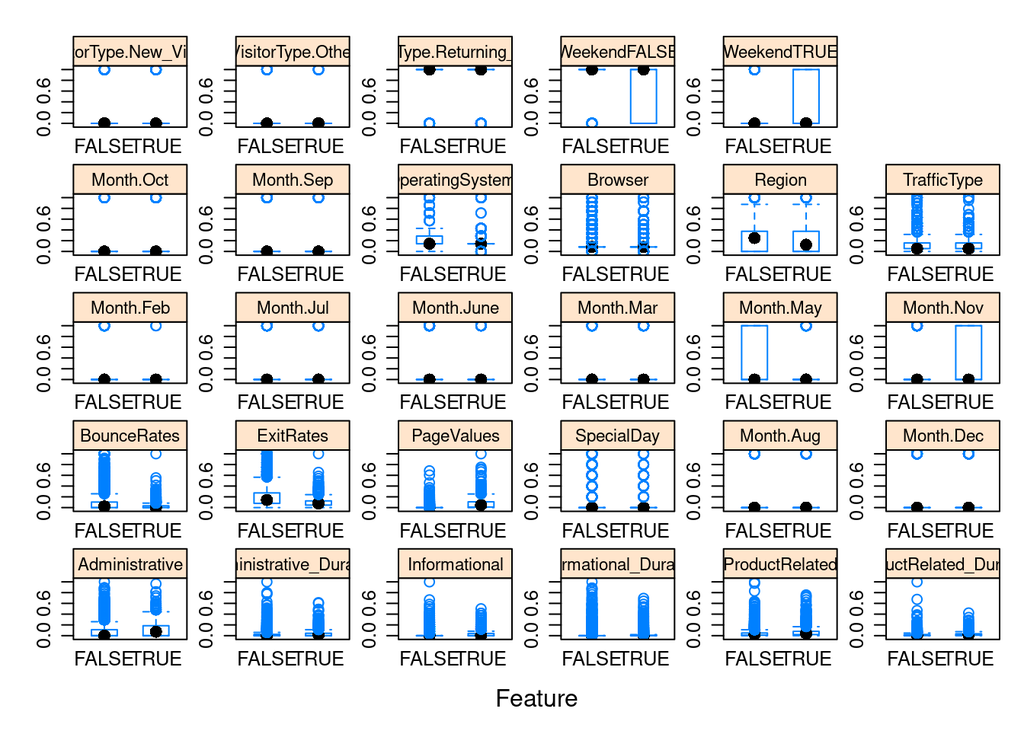

```
##
## Density plot of The Train Data is loading...
```

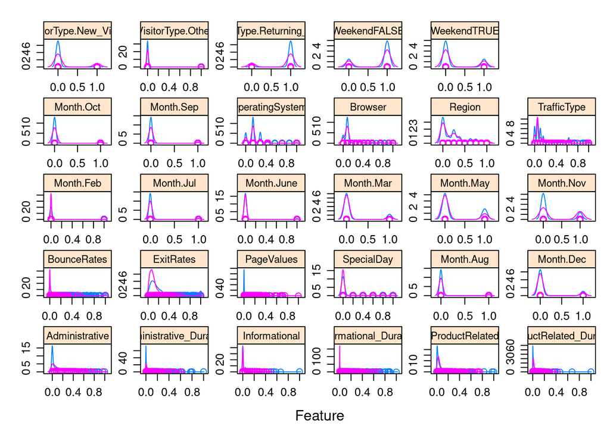

```
##
##   Would you like to see the Model Accuracies and Variable Importance plots
##   of the training models? yes, one-by-one (1) or no, direct comparison (2)? 1
##
## TRAINING
##
##   "knn", "naive_bayes", "lda", "rpart", "adaboost",
##   "bagFDAGCV", "parRF", "rf", "rfRules", "RRF", "gbm",
##   "xgbDART", "xgbLinear", "xgbTree", "bag", "C5.0"
##   "C5.0Cost", "C5.0Rules", "C5.0Tree", "fda", "bagEarth",
##   "bagEarthGCV", "earth", "gcvEarth", "bagFDA", "ranger",
##   "svmLinear2", "svmLinearWeights", "ordinalRF", "treebag"
##   Enter the training method from above list: knn
##   (There are more than these but this script's libraries contains them)
##
## The KNN model is being trained...
##
## KNN Model Accuracies plot loading...
```

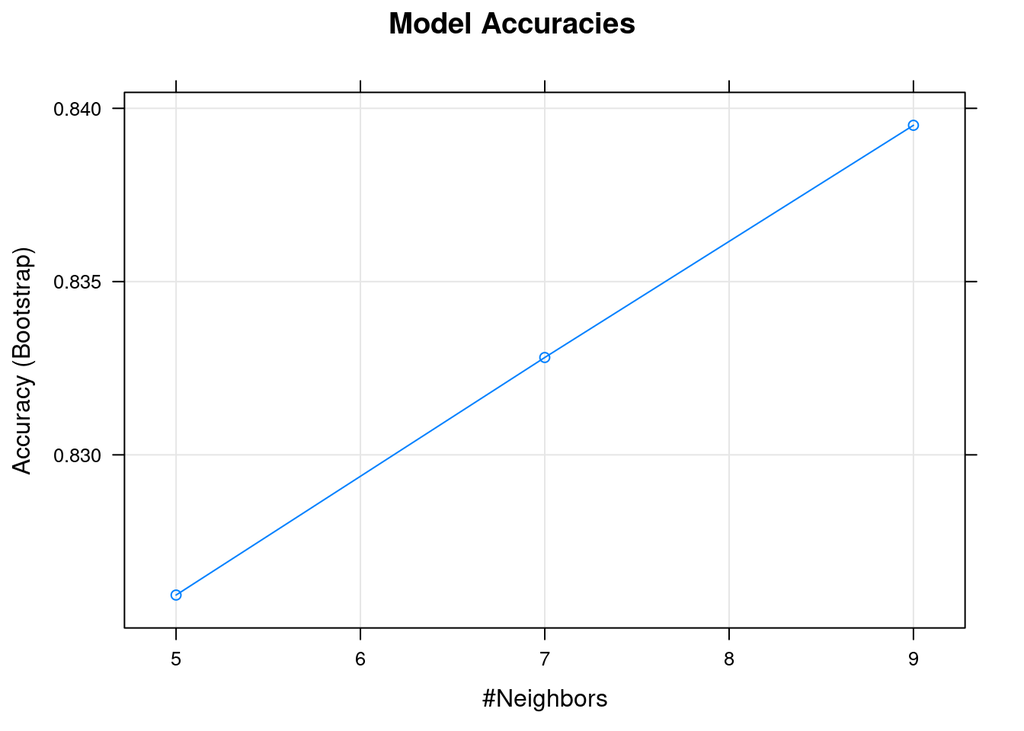

```
##
## KNN Variable Importance plot loading...
```

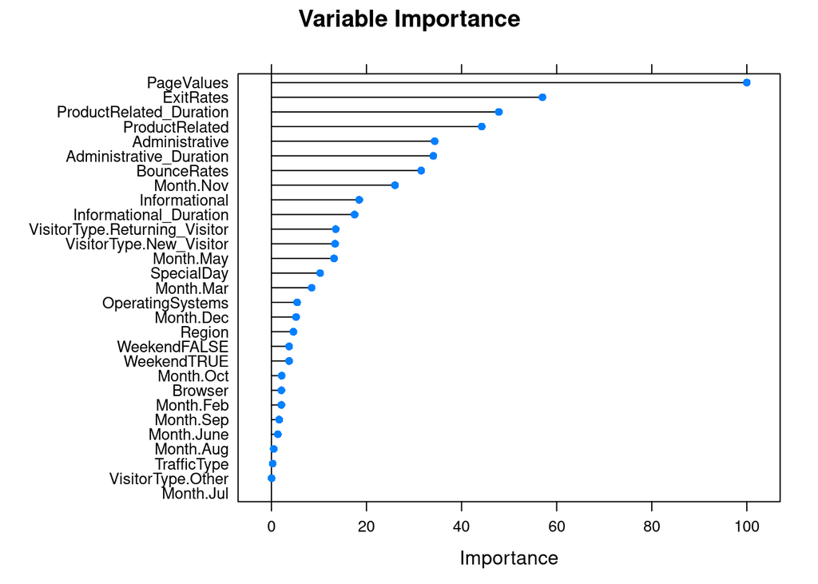

```
##
##   "knn", "naive_bayes", "lda", "rpart", "adaboost",
##   "bagFDAGCV", "parRF", "rf", "rfRules", "RRF", "gbm",
##   "xgbDART", "xgbLinear", "xgbTree", "bag", "C5.0"
##   "C5.0Cost", "C5.0Rules", "C5.0Tree", "fda", "bagEarth",
##   "bagEarthGCV", "earth", "gcvEarth", "bagFDA", "ranger",
##   "svmLinear2", "svmLinearWeights", "ordinalRF", "treebag"
##   Enter the training method from above list: naive_bayes
##   (There are more than these but this script's libraries contains them)
##
## The NAIVE_BAYES model is being trained...
##
## NAIVE_BAYES Model Accuracies plot loading...
```

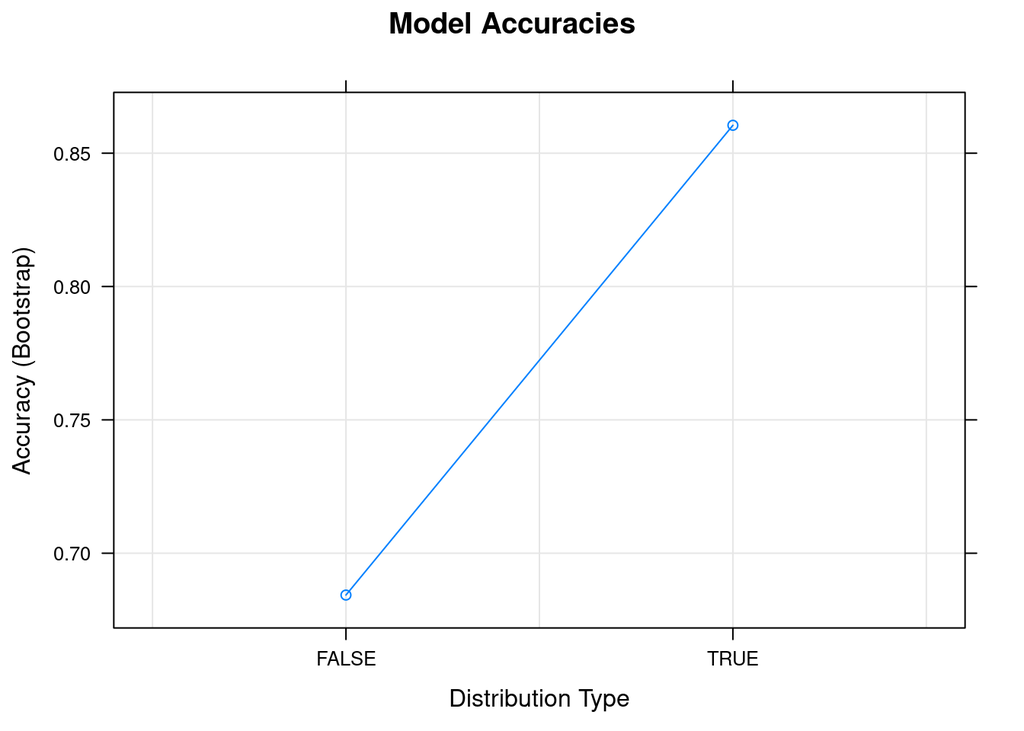

```
##
## NAIVE_BAYES Variable Importance plot loading...
```

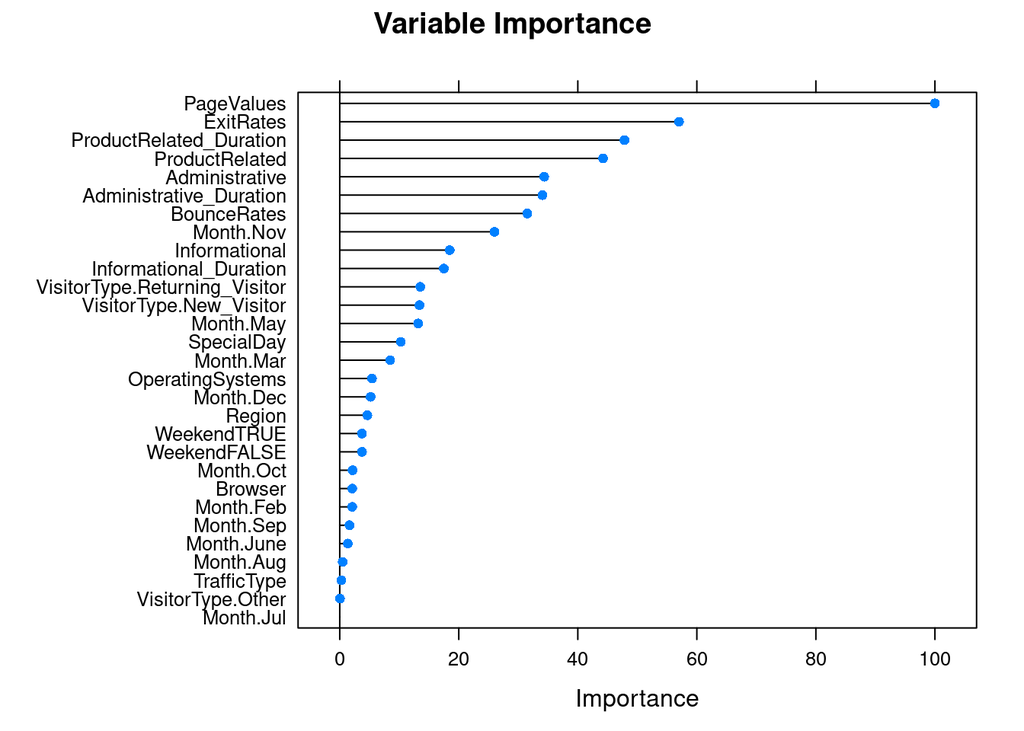

```
##
##   "knn", "naive_bayes", "lda", "rpart", "adaboost",
##   "bagFDAGCV", "parRF", "rf", "rfRules", "RRF", "gbm",
##   "xgbDART", "xgbLinear", "xgbTree", "bag", "C5.0"
##   "C5.0Cost", "C5.0Rules", "C5.0Tree", "fda", "bagEarth",
##   "bagEarthGCV", "earth", "gcvEarth", "bagFDA", "ranger",
##   "svmLinear2", "svmLinearWeights", "ordinalRF", "treebag"
##   Enter the training method from above list: lda
##   (There are more than these but this script's libraries contains them)
##
## The LDA model is being trained...
##
## LDA Model Accuracies plot loading...
## Error in plot.train(training_model, main = "Model Accuracies") :
##   There are no tuning parameters for this model.
##
## LDA Variable Importance plot loading...
```

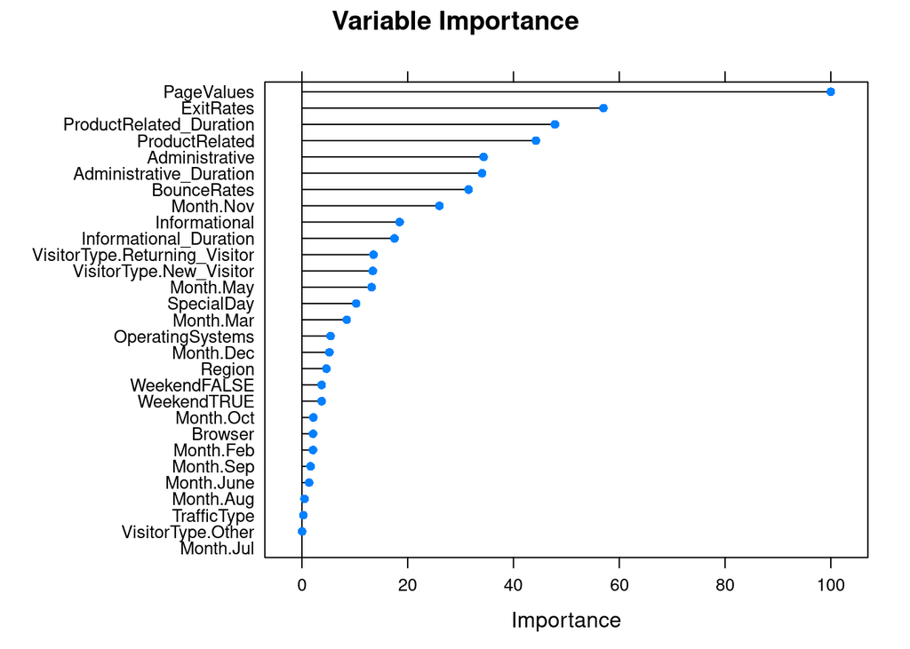

```
##
##   "knn", "naive_bayes", "lda", "rpart", "adaboost",
##   "bagFDAGCV", "parRF", "rf", "rfRules", "RRF", "gbm",
##   "xgbDART", "xgbLinear", "xgbTree", "bag", "C5.0"
##   "C5.0Cost", "C5.0Rules", "C5.0Tree", "fda", "bagEarth",
##   "bagEarthGCV", "earth", "gcvEarth", "bagFDA", "ranger",
##   "svmLinear2", "svmLinearWeights", "ordinalRF", "treebag"
##   Enter the training method from above list: earth
##   (There are more than these but this script's libraries contains them)
##
## The EARTH model is being trained...
##
## EARTH Model Accuracies plot loading...
```

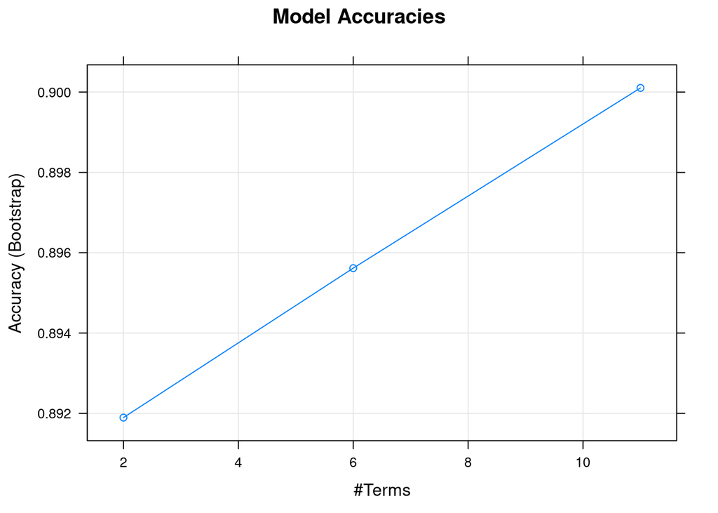

```
##
## EARTH Variable Importance plot loading...
```

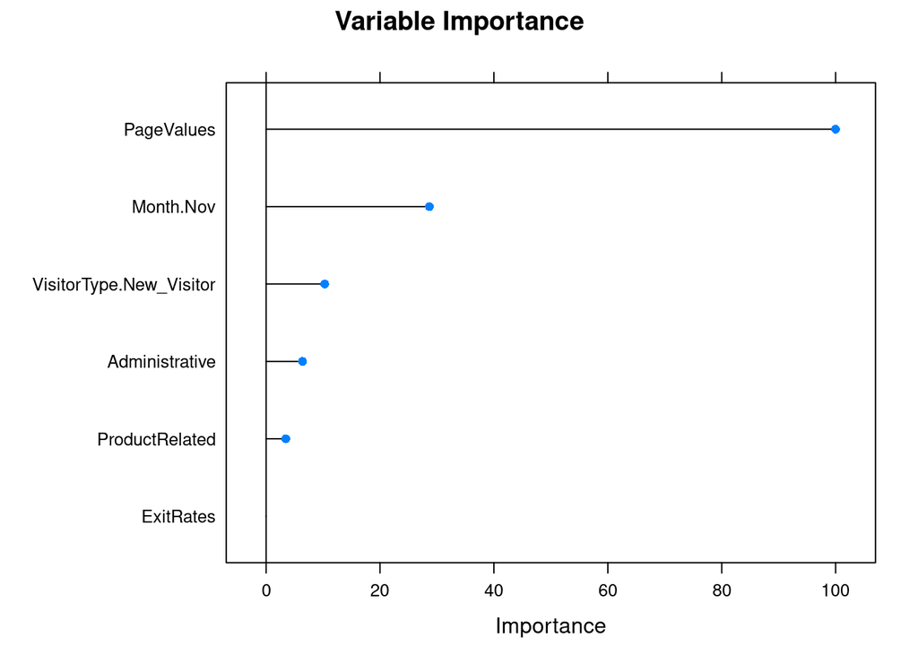

```
##
##   "knn", "naive_bayes", "lda", "rpart", "adaboost",
##   "bagFDAGCV", "parRF", "rf", "rfRules", "RRF", "gbm",
##   "xgbDART", "xgbLinear", "xgbTree", "bag", "C5.0"
##   "C5.0Cost", "C5.0Rules", "C5.0Tree", "fda", "bagEarth",
##   "bagEarthGCV", "earth", "gcvEarth", "bagFDA", "ranger",
##   "svmLinear2", "svmLinearWeights", "ordinalRF", "treebag"
##   Enter the training method from above list: fda
##   (There are more than these but this script's libraries contains them)
##
## The FDA model is being trained...
##
## FDA Model Accuracies plot loading...
```

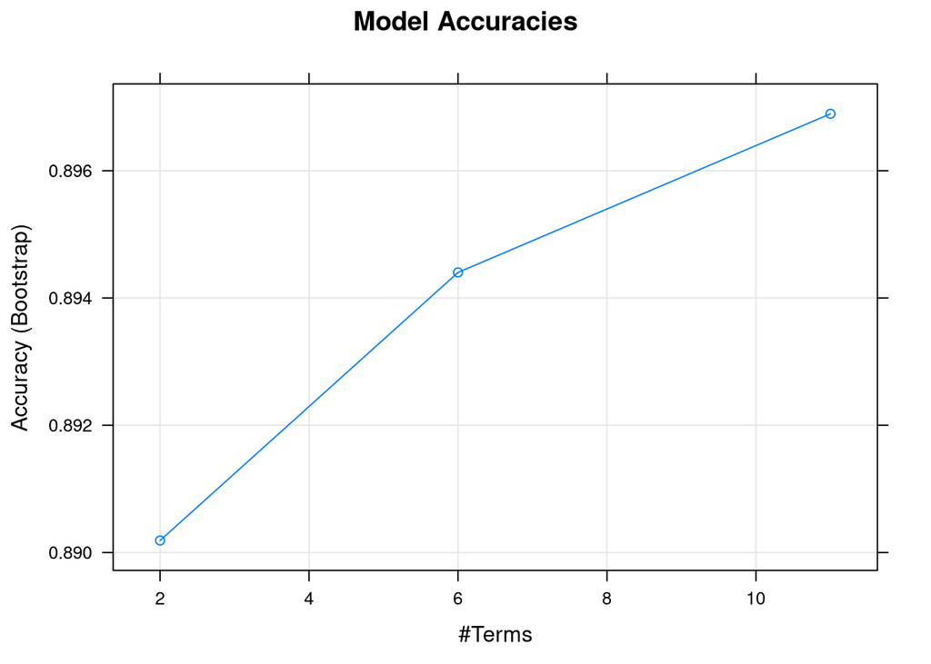

```
##
## FDA Variable Importance plot loading...
```

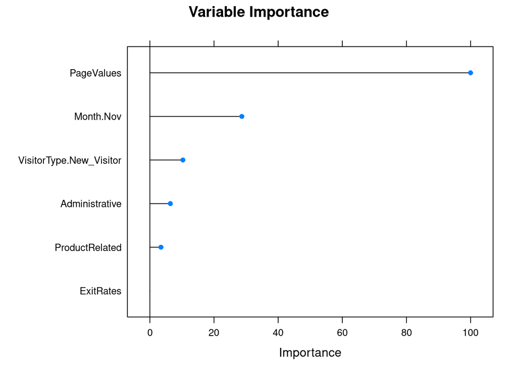

```
##
##
## Call:
## summary.resamples(object = models_compare)
##
## Models: knn, naive_bayes, lda, earth, fda
## Number of resamples: 25
##
## Accuracy
##                  Min.   1st Qu.    Median      Mean   3rd Qu.      Max. NA's
## knn         0.8300191 0.8365411 0.8389482 0.8395105 0.8419346 0.8538124    0
## naive_bayes 0.8499303 0.8577325 0.8612022 0.8604617 0.8645517 0.8666293    0
## lda         0.8758678 0.8803630 0.8827586 0.8830559 0.8861346 0.8894893    0
## earth       0.8939772 0.8981353 0.8993711 0.9001041 0.9019824 0.9075925    0
## fda         0.8887039 0.8938809 0.8957691 0.8968941 0.8995597 0.9075925    0
##
## Kappa
##                   Min.   1st Qu.    Median      Mean   3rd Qu.      Max. NA's
## knn         0.15125484 0.1731608 0.1944564 0.1889336 0.2013940 0.2289091    0
## naive_bayes 0.03673505 0.1766722 0.1982627 0.1943825 0.2170204 0.2776185    0
## lda         0.39327116 0.4081142 0.4215090 0.4220005 0.4363977 0.4522794    0
## earth       0.56405733 0.5787796 0.5883721 0.5882411 0.5962216 0.6256172    0
## fda         0.58434766 0.5986537 0.6057418 0.6091433 0.6172492 0.6423223    0
##
## Model Compare plot is loading...
```

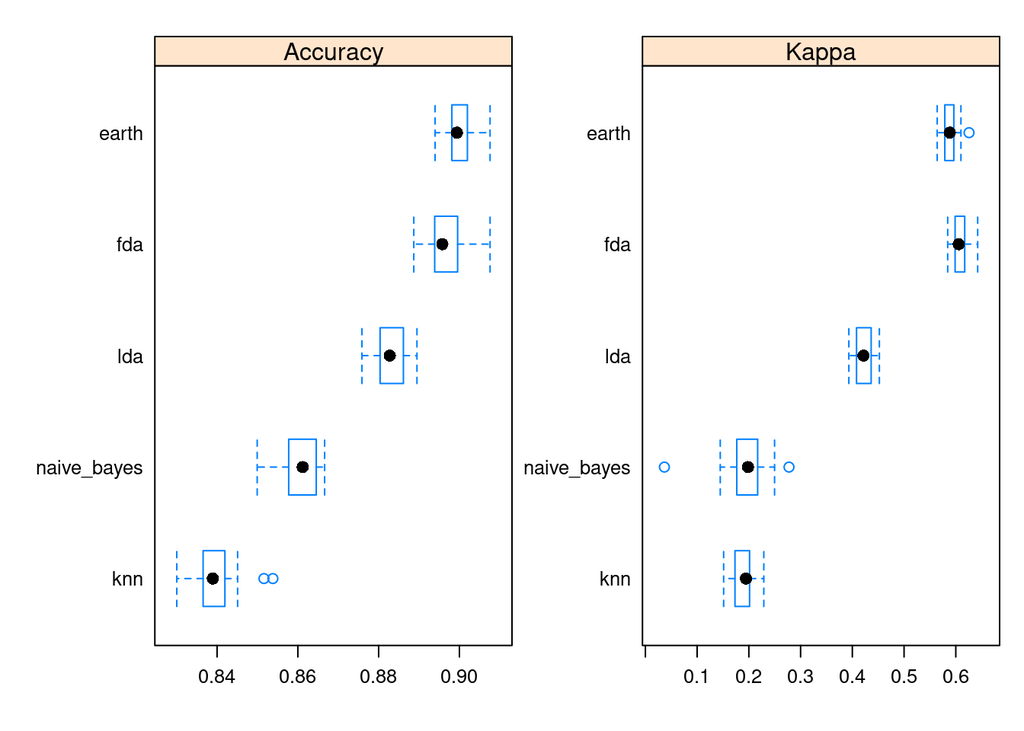

```
##
## PREDICTION
##
## Test data after preprocessing models are applied:
## 'data.frame':    2465 obs. of  29 variables:
##  $ Administrative               : num  0 0 0 0 0.037 ...
##  $ Administrative_Duration      : num  0 0 0 0 0.00265 ...
##  $ Informational                : num  0 0 0 0 0 0 0 0 0 0 ...
##  $ Informational_Duration       : num  0 0 0 0 0 0 0 0 0 0 ...
##  $ ProductRelated               : num  0.00142 0.00426 0.00284 0.00142 0.06525 ...
##  $ ProductRelated_Duration      : num  0 0.00617 0.00106 0 0.06385 ...
##  $ BounceRates                  : num  1 0 0 1 0 ...
##  $ ExitRates                    : num  1 0.33333 0.5 1 0.00897 ...
##  $ PageValues                   : num  0 0 0 0 0 0 0 0 0 0 ...
##  $ SpecialDay                   : num  0 0 0 0 0 0 0 0 0.2 0.4 ...
##  $ Month.Aug                    : num  0 0 0 0 0 0 0 0 0 0 ...
##  $ Month.Dec                    : num  0 0 0 0 0 0 0 0 0 0 ...
##  $ Month.Feb                    : num  1 1 1 1 1 1 1 1 1 1 ...
##  $ Month.Jul                    : num  0 0 0 0 0 0 0 0 0 0 ...
##  $ Month.June                   : num  0 0 0 0 0 0 0 0 0 0 ...
##  $ Month.Mar                    : num  0 0 0 0 0 0 0 0 0 0 ...
##  $ Month.May                    : num  0 0 0 0 0 0 0 0 0 0 ...
##  $ Month.Nov                    : num  0 0 0 0 0 0 0 0 0 0 ...
##  $ Month.Oct                    : num  0 0 0 0 0 0 0 0 0 0 ...
##  $ Month.Sep                    : num  0 0 0 0 0 0 0 0 0 0 ...
##  $ OperatingSystems             : num  0.429 0 0.286 0 0.143 ...
##  $ Browser                      : num  0 0 0.0833 0 0.0833 ...
##  $ Region                       : num  1 0.25 0.25 0.375 0.875 0.375 0 0.125 0 0.625 ...
##  $ TrafficType                  : num  0.105 0.105 0.105 0.105 0.158 ...
##  $ VisitorType.New_Visitor      : num  0 0 0 0 0 0 0 0 0 0 ...
##  $ VisitorType.Other            : num  0 0 0 0 0 0 0 0 0 0 ...
##  $ VisitorType.Returning_Visitor: num  1 1 1 1 1 1 1 1 1 1 ...
##  $ WeekendFALSE                 : num  1 1 1 1 1 1 1 1 1 1 ...
##  $ WeekendTRUE                  : num  0 0 0 0 0 0 0 0 0 0 ...
## NULL
##
##
## PREDICTING TEST DATA WITH ALL MODELS
## 1 . For KNN model:
## Confusion Matrix and Statistics
```

[output cut: 142 more lines]

```
##
##             Sensitivity : 0.9285
##             Specificity : 0.6772
##          Pos Pred Value : 0.9402
##          Neg Pred Value : 0.6339
##               Precision : 0.9402
##                  Recall : 0.9285
##                      F1 : 0.9343
##              Prevalence : 0.8454
##          Detection Rate : 0.7850
##    Detection Prevalence : 0.8349
##       Balanced Accuracy : 0.8028
##
##        'Positive' Class : FALSE
##
```